# Agoda Case Testing

**Agoda Case Study**

This is the Jupyter Notebook for analyzing the Agoda Case Study.

**Introduction**

Most of the time, the primary goal of launching a new feature on Agoda website is to increase the number of bookings. One way to increase the number of bookings and conversion rate is to encourage customers to complete their booking as fast as possible. The call to action message that helps us to achieve that is internally known as an ‘urgency message’.

A Product Owner (PO) would like to implement an urgency message on the website such as

- “Prices have been rising. Book now to lock in your rates!”
- “Your check-in is fast approaching. Book now to lock in your rates!”

**Goal: He/she is requesting you to perform an analysis in order to understand the movement of the price as the day approaches the check-in date.** Attached is a randomly sampled booking data from five different cities with check-in between 10/10/2016 – 12/31/2016.

Some things to think about

- At which part of the funnel should this message be implemented? On a homepage, search results page, at the property level, or booking form?
- What assumptions are you making about the data?
- What factors play a role on price in this analysis?
- What other factors may influence the analysis that isn’t available in the dataset? What would improve the analysis?
- What conclusions can you draw from the data?
- What recommendations would you give to the Product Owner?

Data Dictionary  
'#' - No of record in each dataset  
ADR – Average Daily Rate in US Dollars (Customer Total Amount / Room Nights)  
Hotel ID – Property identification number  
City ID – City identification number  
Star rating – Property’s star rating  
Accommodation Type Name – Property’s accommodation type  
Chain Hotel – Indicates whether the property is part of a chain or not  
Booking date – Date of booking made  
Check-in date – Date of check-in  
Check-out date – Date of check-out

```python
import numpy as np
import pandas as pd
from pandas import ExcelWriter
from pandas import ExcelFile
from datetime import datetime, date
import matplotlib.pyplot as plt
import seaborn as sns
sns.set(style = "whitegrid",
        color_codes = True,
        font_scale = 1.5)
```

```python
from IPython.core.interactiveshell import InteractiveShell
InteractiveShell.ast_node_interactivity = "all"
```

```python
exA = pd.read_excel('Case_Study_Urgency_Message_Data.xlsx', sheet_name = 'City_A')
exB = pd.read_excel('Case_Study_Urgency_Message_Data.xlsx', sheet_name = 'City_B')
exC = pd.read_excel('Case_Study_Urgency_Message_Data.xlsx', sheet_name = 'City_C')
exD = pd.read_excel('Case_Study_Urgency_Message_Data.xlsx', sheet_name = 'City_D')
exE = pd.read_excel('Case_Study_Urgency_Message_Data.xlsx', sheet_name = 'City_E')
```

```python
exA.head(5)
# exB.tail(5)
```

[output not shown]

Adding some useful columns in the dataframe for all 5 cities.

```python
exA['booking_month'] = exA['booking_date'].dt.month
exA['checkin_month'] = exA['checkin_date'].dt.month
exA['booked_days_ahead'] = exA['checkin_date'] - exA['booking_date']
exA['bookdays_int'] = exA['booked_days_ahead'].dt.days
exA['day_of_week'] = exA['checkin_date'].dt.day_name()
exA.head()

exB['booking_month'] = exB['booking_date'].dt.month
exB['checkin_month'] = exB['checkin_date'].dt.month
exB['booked_days_ahead'] = exB['checkin_date'] - exB['booking_date']
exB['bookdays_int'] = exB['booked_days_ahead'].dt.days
exB['day_of_week'] = exB['checkin_date'].dt.day_name()
exB.head()

exC['booking_month'] = exC['booking_date'].dt.month
exC['checkin_month'] = exC['checkin_date'].dt.month
exC['booked_days_ahead'] = exC['checkin_date'] - exC['booking_date']
exC['bookdays_int'] = exC['booked_days_ahead'].dt.days
exC['day_of_week'] = exC['checkin_date'].dt.day_name()
exC.head()

exD['booking_month'] = exD['booking_date'].dt.month
exD['checkin_month'] = exD['checkin_date'].dt.month
exD['booked_days_ahead'] = exD['checkin_date'] - exD['booking_date']
exD['bookdays_int'] = exD['booked_days_ahead'].dt.days
exD['day_of_week'] = exD['checkin_date'].dt.day_name()
exD.head()

exE['booking_month'] = exE['booking_date'].dt.month
exE['checkin_month'] = exE['checkin_date'].dt.month
exE['booked_days_ahead'] = exE['checkin_date'] - exE['booking_date']
exE['bookdays_int'] = exE['booked_days_ahead'].dt.days
exE['day_of_week'] = exE['checkin_date'].dt.day_name()
exE.head()
```

|  | # | ADR_USD | hotel_id | city_id | star_rating | accommodation_type_name | chain_hotel | booking_date | checkin_date | checkout_date | booking_month | checkin_month | booked_days_ahead | bookdays_int | day_of_week |
| --- | --- | --- | --- | --- | --- | --- | --- | --- | --- | --- | --- | --- | --- | --- | --- |
| 0 | 1 | 90.60 | 374026 | 8584 | 4.0 | Hotel | chain | 2016-08-08 | 2016-10-06 | 2016-10-07 | 8 | 10 | 59 days | 59 | Thursday |
| 1 | 2 | 65.70 | 1167514 | 8584 | 3.0 | Hotel | non-chain | 2016-08-09 | 2016-10-04 | 2016-10-06 | 8 | 10 | 56 days | 56 | Tuesday |
| 2 | 3 | 73.08 | 1167514 | 8584 | 3.0 | Hotel | non-chain | 2016-08-09 | 2016-10-02 | 2016-10-03 | 8 | 10 | 54 days | 54 | Sunday |
| 3 | 4 | 51.02 | 217094 | 8584 | 3.0 | Serviced Apartment | chain | 2016-08-10 | 2016-10-07 | 2016-10-10 | 8 | 10 | 58 days | 58 | Friday |
| 4 | 5 | 166.16 | 97014 | 8584 | 4.0 | Resort | non-chain | 2016-08-10 | 2016-10-01 | 2016-10-02 | 8 | 10 | 52 days | 52 | Saturday |

Recall the **MAIN Questions** to answer to:

1. **Where** to implement the urgency message? (homepage, search results page, at the property level, or booking form)
2. **When** to start implementing the urgency message?
3. **Which** hotel type to implement urgency message? (non-chain, chain hotel)
4. **Which** accommadation type to implement urgency message? (Resort, Hotel, Guest House)
5. **Time Scale** to implement urgency message? (For holiday season? weekend market?)

**Some Ideas to start with**  
Can suggest that **add total numbers of available rooms to book column**. If not many rooms left, deploy urgency message on other hotels which have more rooms available to book to save the resources.

```python
len(exA)
len(exB)
len(exC)
len(exD)
len(exE)
```

```
4817
```

The number of records:  
City A: 22366  
City B: 4932  
City C: 6797  
City D: 10152  
City E: 4817

Let's just look at one City first. In this case City B for now.

## City C

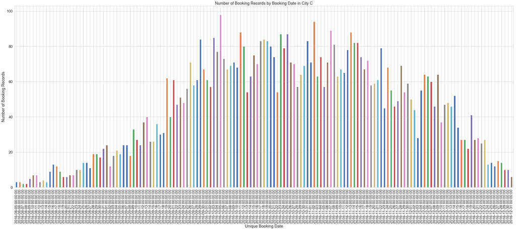

```python
book_date_count_C = exC['booking_date'].groupby([exC['booking_date']]).agg('count')
book_date_count_C

num_book_bookdate_C = plt.figure(figsize=(40, 15))
book_date_count_C.plot(kind="bar")
plt.ylabel("Number of Booking Records")
plt.xlabel("Unique Booking Date")
plt.title("Number of Booking Records by Booking Date in City C");
num_book_bookdate_C.savefig('Pictures/num_book_bookdate_C.png')
```

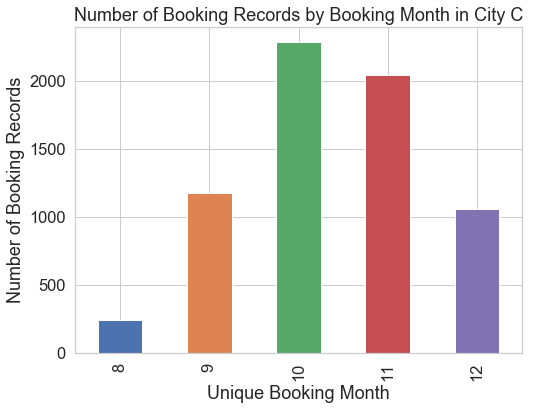

```python
book_month_count_C = exC['booking_date'].groupby([exC['booking_date'].dt.month]).agg('count')
book_month_count_C

num_book_bookmonth_C = plt.figure(figsize=(8, 6))
book_month_count_C.plot(kind="bar")
plt.ylabel("Number of Booking Records")
plt.xlabel("Unique Booking Month")
plt.title("Number of Booking Records by Booking Month in City C");
num_book_bookmonth_C.savefig('Pictures/num_book_bookmonth_C.png')
```

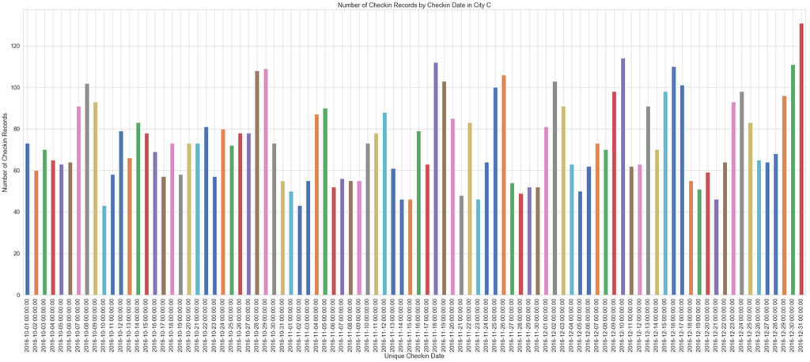

```python
checkin_date_count_C = exC['checkin_date'].groupby([exC['checkin_date']]).agg('count')
checkin_date_count_C

num_book_checkdate_C = plt.figure(figsize=(40, 15))
checkin_date_count_C.plot(kind="bar")
plt.ylabel("Number of Checkin Records")
plt.xlabel("Unique Checkin Date")
plt.title("Number of Checkin Records by Checkin Date in City C");
num_book_checkdate_C.savefig('Pictures/num_book_checkdate_C.png')
```

## City D

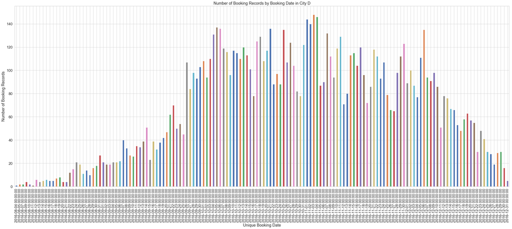

```python
book_date_count_D = exD['booking_date'].groupby([exD['booking_date']]).agg('count')
book_date_count_D

num_book_bookdate_D = plt.figure(figsize=(40, 15))
book_date_count_D.plot(kind="bar")
plt.ylabel("Number of Booking Records")
plt.xlabel("Unique Booking Date")
plt.title("Number of Booking Records by Booking Date in City D");
num_book_bookdate_D.savefig('Pictures/num_book_bookdate_D.png')
```

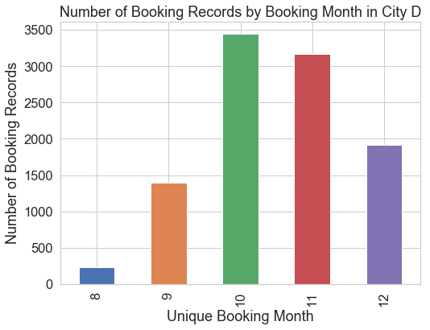

```python
book_month_count_D = exD['booking_date'].groupby([exD['booking_date'].dt.month]).agg('count')
book_month_count_D

num_book_bookmonth_D = plt.figure(figsize=(8, 6))
book_month_count_D.plot(kind="bar")
plt.ylabel("Number of Booking Records")
plt.xlabel("Unique Booking Month")
plt.title("Number of Booking Records by Booking Month in City D");
num_book_bookmonth_D.savefig('Pictures/num_book_bookmonth_D.png')
```

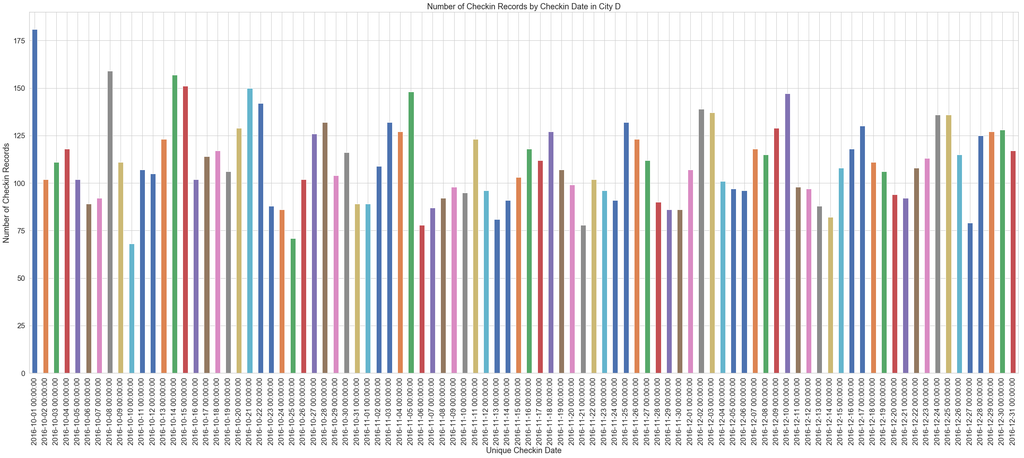

```python
checkin_date_count_D = exD['checkin_date'].groupby([exD['checkin_date']]).agg('count')
checkin_date_count_D

num_book_checkdate_D = plt.figure(figsize=(40, 15))
checkin_date_count_D.plot(kind="bar")
plt.ylabel("Number of Checkin Records")
plt.xlabel("Unique Checkin Date")
plt.title("Number of Checkin Records by Checkin Date in City D");
num_book_checkdate_D.savefig('Pictures/num_book_checkdate_D.png')
```

## City E

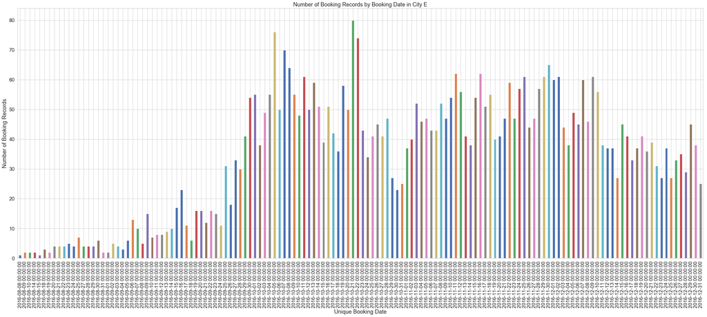

```python
book_date_count_E = exE['booking_date'].groupby([exE['booking_date']]).agg('count')
book_date_count_E

num_book_bookdate_E = plt.figure(figsize=(40, 15))
book_date_count_E.plot(kind="bar")
plt.ylabel("Number of Booking Records")
plt.xlabel("Unique Booking Date")
plt.title("Number of Booking Records by Booking Date in City E");
num_book_bookdate_E.savefig('Pictures/num_book_bookdate_E.png')
```

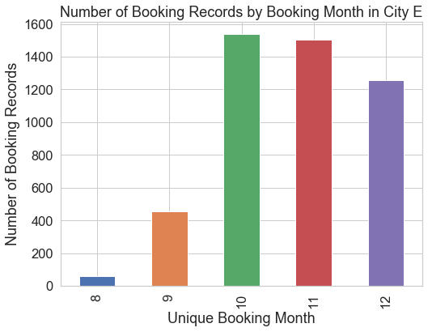

```python
book_month_count_E = exE['booking_date'].groupby([exE['booking_date'].dt.month]).agg('count')
book_month_count_E

num_book_bookmonth_E = plt.figure(figsize=(8, 6))
book_month_count_E.plot(kind="bar")
plt.ylabel("Number of Booking Records")
plt.xlabel("Unique Booking Month")
plt.title("Number of Booking Records by Booking Month in City E");
num_book_bookmonth_E.savefig('Pictures/num_book_bookmonth_E.png')
```

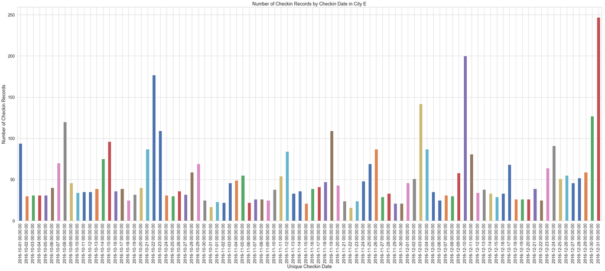

```python
checkin_date_count_E = exE['checkin_date'].groupby([exE['checkin_date']]).agg('count')
checkin_date_count_E

num_book_checkdate_E = plt.figure(figsize=(40, 15))
checkin_date_count_E.plot(kind="bar")
plt.ylabel("Number of Checkin Records")
plt.xlabel("Unique Checkin Date")
plt.title("Number of Checkin Records by Checkin Date in City E");
num_book_checkdate_E.savefig('Pictures/num_book_checkdate_E.png')
```

## City B

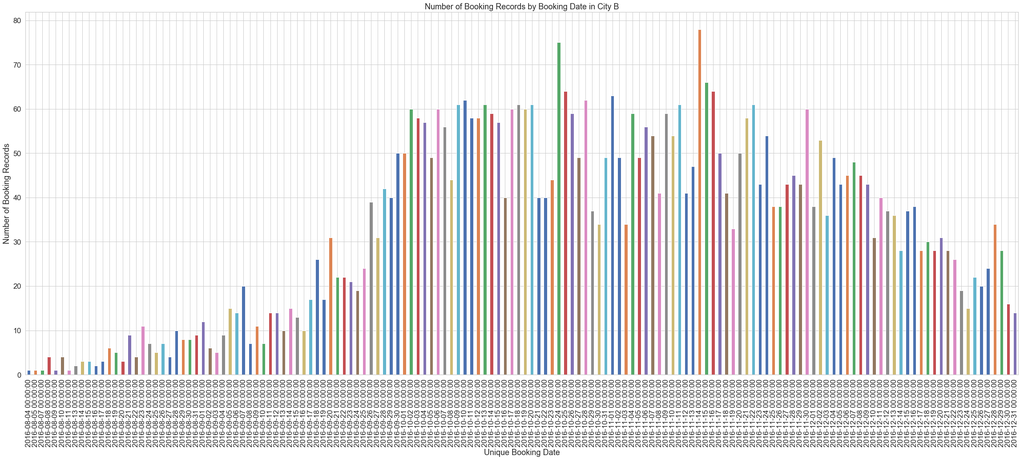

```python
book_date_count_B = exB['booking_date'].groupby([exB['booking_date']]).agg('count')
book_date_count_B

num_book_bookdate_B = plt.figure(figsize=(40, 15))
book_date_count_B.plot(kind="bar")
plt.ylabel("Number of Booking Records")
plt.xlabel("Unique Booking Date")
plt.title("Number of Booking Records by Booking Date in City B");
num_book_bookdate_B.savefig('Pictures/num_book_bookdate_B.png')
```

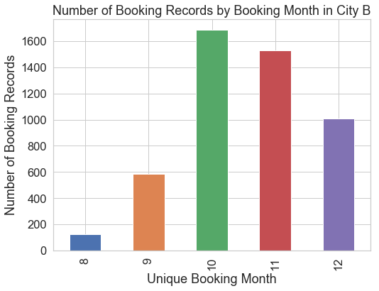

```python
book_month_count_B = exB['booking_date'].groupby([exB['booking_date'].dt.month]).agg('count')
book_month_count_B

num_book_bookmonth_B = plt.figure(figsize=(8, 6))
book_month_count_B.plot(kind="bar")
plt.ylabel("Number of Booking Records")
plt.xlabel("Unique Booking Month")
plt.title("Number of Booking Records by Booking Month in City B");
num_book_bookmonth_B.savefig('Pictures/num_book_bookmonth_B.png')
```

```python
exB['booking_date'].value_counts().head(3)
```

```
2016-11-14    78
2016-10-24    75
2016-11-15    66
Name: booking_date, dtype: int64
```

We can see that in City B, the top three dates that has the highest booking records is 11/14 (78 records), 10/24 (75 records), 11/15 (66 records).

```python
exB['checkin_date'].value_counts().head(3)
```

```
2016-12-31    94
2016-12-30    87
2016-10-14    79
Name: checkin_date, dtype: int64
```

We can see that in City B, the top three dates that has the highest checkin records is 12/31 (94 records), 12/30 (87 records), 10/14 (79 records).

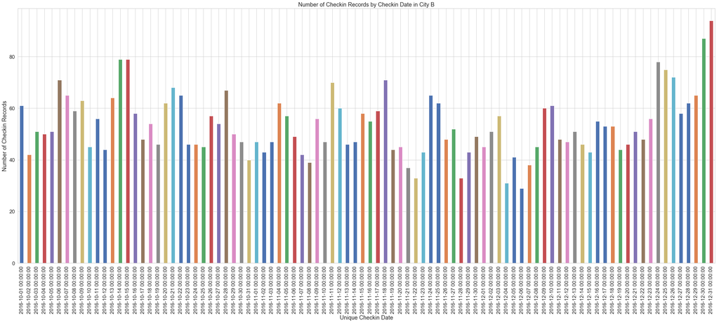

```python
checkin_date_count_B = exB['checkin_date'].groupby([exB['checkin_date']]).agg('count')
checkin_date_count_B

num_book_checkdate_B = plt.figure(figsize=(40, 15))
checkin_date_count_B.plot(kind="bar")
plt.ylabel("Number of Checkin Records")
plt.xlabel("Unique Checkin Date")
plt.title("Number of Checkin Records by Checkin Date in City B");
num_book_checkdate_B.savefig('Pictures/num_book_checkdate_B.png')
```

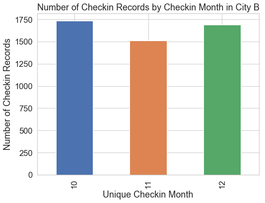

```python
checkin_month_count_B = exB['checkin_date'].groupby([exB['checkin_date'].dt.month]).agg('count')
checkin_month_count_B

plt.figure(figsize=(8, 6))
checkin_month_count_B.plot(kind="bar")
plt.ylabel("Number of Checkin Records")
plt.xlabel("Unique Checkin Month")
plt.title("Number of Checkin Records by Checkin Month in City B");
```

The number of Checkin records in each month also seems to be spread out equally compare to the number of Booking records in each month.

The number of checkin record's distribution looks more spread out equally compare to the number of booking record's distribution. However, there seems to be some kind of seasonal factors in the distribution (by Dates). Let's take a look at the checkin record's distribution in a different city. City A in this case, since it has the most record. Which might indicate that it is a bigger city, therefore, lead to a more general result.

## City A

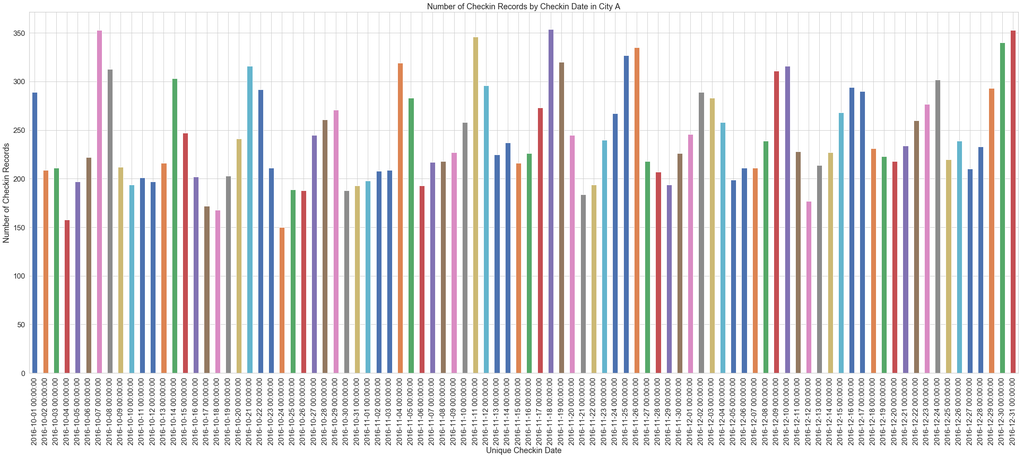

```python
checkin_date_count_A = exA['checkin_date'].groupby([exA['checkin_date']]).agg('count')
checkin_date_count_A

num_book_checkdate_A = plt.figure(figsize=(40, 15))
checkin_date_count_A.plot(kind="bar")
plt.ylabel("Number of Checkin Records")
plt.xlabel("Unique Checkin Date")
plt.title("Number of Checkin Records by Checkin Date in City A");
num_book_checkdate_A.savefig('Pictures/num_book_checkdate_A.png')
```

It is very clear now, that there indeed is a seasonal factor. We can see that there is always two higher number of records in every 7 days.  
For example:  
10/07 and 10/08  
10/14 and 10/15  
10/21 and 10/22  
...  
This might indicate that these days are weekends (Fridar/Saturday/Sunday), therefore, having more checkin records.  
By checking the calendar at the exact time in 2016. These days turns out to be the Fridays and the Saturdays.

In addition to implementing the urgency message before the holiday season starts, we can also focus on the booking increase for the weekend checkin days. Let's call this **the weekend market** as a shorthand.

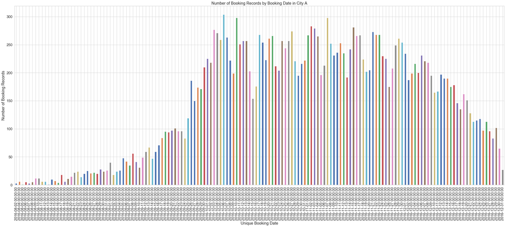

```python
book_date_count_A = exA['booking_date'].groupby([exA['booking_date']]).agg('count')
book_date_count_A

num_book_bookdate_A = plt.figure(figsize=(40, 15))
book_date_count_A.plot(kind="bar")
plt.ylabel("Number of Booking Records")
plt.xlabel("Unique Booking Date")
plt.title("Number of Booking Records by Booking Date in City A");
num_book_bookdate_A.savefig('Pictures/num_book_bookdate_A.png')
```

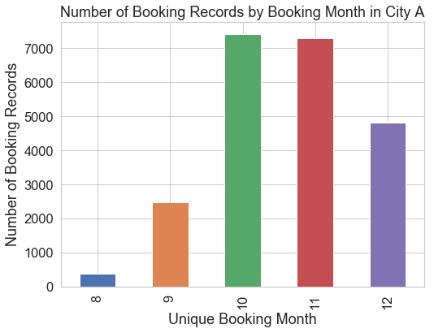

```python
book_month_count_A = exA['booking_date'].groupby([exA['booking_date'].dt.month]).agg('count')
book_month_count_A

num_book_bookmonth_A = plt.figure(figsize=(8, 6))
book_month_count_A.plot(kind="bar")
plt.ylabel("Number of Booking Records")
plt.xlabel("Unique Booking Month")
plt.title("Number of Booking Records by Booking Month in City A");
num_book_bookmonth_A.savefig('Pictures/num_book_bookmonth_A.png')
```

Take a closer look at the time starting from October. Let's zoom in a little bit.

```python
exA['booking_month'] = exA['booking_date'].dt.month
exA.tail(5)
# getting the records that is after September (starting with October)
exA_101112 = exA[exA['booking_month'] > 9]
exA_101112.head(5)
```

|  | # | ADR_USD | hotel_id | city_id | star_rating | accommadation_type_name | chain_hotel | booking_date | checkin_date | checkout_date | booking_month |
| --- | --- | --- | --- | --- | --- | --- | --- | --- | --- | --- | --- |
| 2846 | 2847 | 104.14 | 21272 | 9395 | 4.0 | Hotel | non-chain | 2016-10-01 | 2016-10-01 | 2016-10-02 | 10 |
| 2847 | 2848 | 80.96 | 782884 | 9395 | 3.0 | Hotel | chain | 2016-10-01 | 2016-10-29 | 2016-10-31 | 10 |
| 2848 | 2849 | 80.96 | 782884 | 9395 | 3.0 | Hotel | chain | 2016-10-01 | 2016-10-29 | 2016-10-31 | 10 |
| 2849 | 2850 | 182.76 | 96982 | 9395 | 4.0 | Hotel | chain | 2016-10-01 | 2016-10-27 | 2016-10-30 | 10 |
| 2850 | 2851 | 62.97 | 866630 | 9395 | 3.5 | Serviced Apartment | non-chain | 2016-10-01 | 2016-10-08 | 2016-10-10 | 10 |

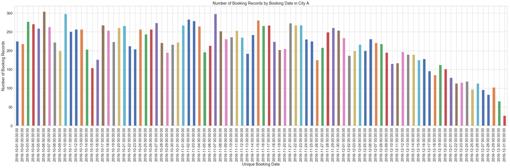

```python
book_date_count_A_10 = exA_101112['booking_date'].groupby([exA_101112['booking_date']]).agg('count')
book_date_count_A_10

plt.figure(figsize=(40, 10))
book_date_count_A_10.plot(kind="bar")
plt.ylabel("Number of Booking Records")
plt.xlabel("Unique Booking Date")
plt.title("Number of Booking Records by Booking Date in City A");
```

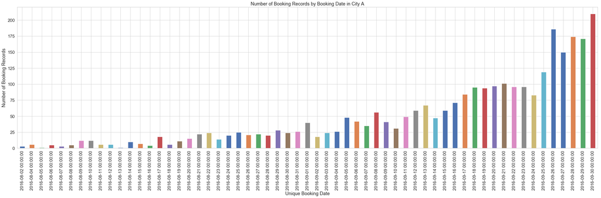

```python
exA_89 = exA[exA['booking_month'] < 10]
exA_89.tail(5)

book_date_count_A_89 = exA_89['booking_date'].groupby([exA_89['booking_date']]).agg('count')
book_date_count_A_89

plt.figure(figsize=(40, 10))
book_date_count_A_89.plot(kind="bar")
plt.ylabel("Number of Booking Records")
plt.xlabel("Unique Booking Date")
plt.title("Number of Booking Records by Booking Date in City A");
```

```python
exA['accommadation_type_name'].value_counts()
```

```
Hotel                            18398
Serviced Apartment                2326
Hostel                            1002
Guest House / Bed & Breakfast      520
Apartment                           51
Resort                              33
Motel                               27
Ryokan                               9
Name: accommadation_type_name, dtype: int64
```

In City A out of the 22366 total records, 18398 records belongs to "Hotel" type (which is about 82.25%), whereas the 2nd high record, "Serviced Apartment", has 2326 records that only represents 10% of the total.  
Therefore, we can say that in City A "Hotel" type has the biggest market among other accommadation types.

On the other hand, in City B, out of the 4932 total records, 1930 records belongs to "Resort" (39.1%), and the 2nd high record is "Hotel", for having 1890 records (38.3%), and the 3rd high record is "Guest House", for having 532 records (10.8%)

```python
exB['accommadation_type_name'].value_counts()
```

```
Resort                           1930
Hotel                            1890
Guest House / Bed & Breakfast     532
Resort Villa                      299
Bungalow                          141
Serviced Apartment                 70
Apartment                          34
Hostel                             17
Private Villa                      15
Holiday Park / Caravan Park         3
Villa                               1
Name: accommadation_type_name, dtype: int64
```

```python
exC['accommodation_type_name'].value_counts()
```

```
Hotel                            4830
Capsule Hotel                     822
Hostel                            408
Guest House / Bed & Breakfast     374
Apartment                         137
Resort                            126
Ryokan                             94
Love Hotel                          3
Serviced Apartment                  2
Home                                1
Name: accommodation_type_name, dtype: int64
```

```python
exD['accommodation_type_name'].value_counts()
```

```
Hotel                            7783
Hostel                           1269
Guest House / Bed & Breakfast     991
Serviced Apartment                 97
Home                               12
Name: accommodation_type_name, dtype: int64
```

```python
exE['accommodation_type_name'].value_counts()
```

```
Hotel                            2540
Resort                           1436
Guest House / Bed & Breakfast     341
Serviced Apartment                302
Resort Villa                       98
Hostel                             78
Apartment                          17
Private Villa                       3
Home                                1
Bungalow                            1
Name: accommodation_type_name, dtype: int64
```

One thing to notice: In City A and City B the column is misspelt ad "accommadation_type_name", whereas in City C, City D, City E it is spell as "accommodation_type_name"

The Top 1 accommodation type that has the most records in each city:  
City A: Hotel (82.25%)  
City B: Resort (39.1%)  
City C: Hotel (71%)  
City D: Hotel (76.66%)  
City E: Hotel (52.73%)

```python
exB['chain_hotel'].value_counts()
```

```
non-chain    3882
chain        1050
Name: chain_hotel, dtype: int64
```

Let's use the result of the Top Accommodation type and combine it with the booking record plot to see if there is some kind of relationship between the price and the amount of booking records.

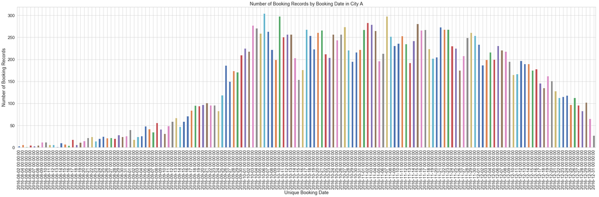

```python
book_date_count_A = exA['booking_date'].groupby([exA['booking_date']]).agg('count')
book_date_count_A

plt.figure(figsize=(40, 10))
book_date_count_A.plot(kind="bar")
plt.ylabel("Number of Booking Records")
plt.xlabel("Unique Booking Date")
plt.title("Number of Booking Records by Booking Date in City A");
```

```python
exA.head()
```

|  | # | ADR_USD | hotel_id | city_id | star_rating | accommadation_type_name | chain_hotel | booking_date | checkin_date | checkout_date | booking_month |
| --- | --- | --- | --- | --- | --- | --- | --- | --- | --- | --- | --- |
| 0 | 1 | 71.06 | 297388 | 9395 | 2.5 | Hotel | non-chain | 2016-08-02 | 2016-10-01 | 2016-10-02 | 8 |
| 1 | 2 | 76.56 | 298322 | 9395 | 3.0 | Hotel | non-chain | 2016-08-02 | 2016-10-01 | 2016-10-02 | 8 |
| 2 | 3 | 153.88 | 2313076 | 9395 | 5.0 | Hotel | chain | 2016-08-02 | 2016-10-01 | 2016-10-02 | 8 |
| 3 | 4 | 126.60 | 2240838 | 9395 | 3.5 | Hotel | non-chain | 2016-08-04 | 2016-10-02 | 2016-10-03 | 8 |
| 4 | 5 | 115.08 | 2240838 | 9395 | 3.5 | Hotel | non-chain | 2016-08-04 | 2016-10-02 | 2016-10-03 | 8 |

###### #

```python
exA['checkin_date'].value_counts().head()
exB['checkin_date'].value_counts().head()
exC['checkin_date'].value_counts().head()
exD['checkin_date'].value_counts().head()
exE['checkin_date'].value_counts().head()
```

```
2016-12-31    247
2016-12-10    200
2016-10-22    177
2016-12-03    142
2016-12-30    127
Name: checkin_date, dtype: int64
```

###### #

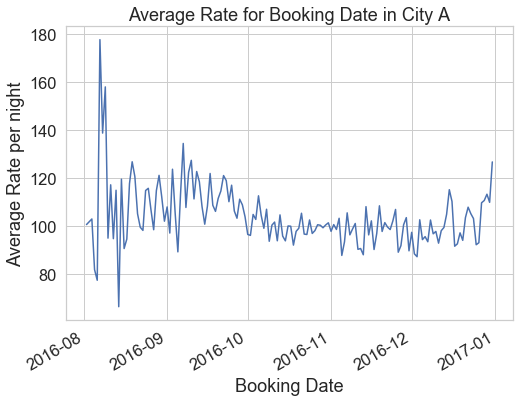

```python
book_date_price_A = exA['ADR_USD'].groupby([exA['booking_date']]).agg('mean')
book_date_price_A

ADR_bookdate_A = plt.figure(figsize=(8, 6))
book_date_price_A.plot(kind="line")
plt.xlabel("Booking Date")
plt.ylabel("Average Rate per night");
plt.title("Average Rate for Booking Date in City A")
ADR_bookdate_A.savefig('Pictures/ADR_bookdate_A.png')
```

Doesn't make sense to me. Because in our assumption, we should have higher rates when it's close to the holiday seasons. Maybe let's look at the seperate price for different accommodation type.

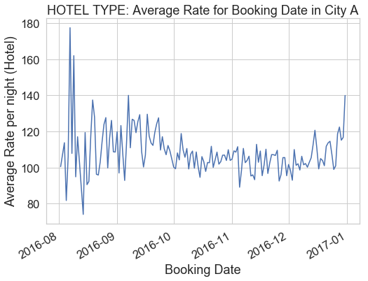

```python
book_date_price_acco_A = exA['ADR_USD'].groupby([exA['accommadation_type_name'], exA['booking_date']]).agg('mean')
book_date_price_acco_A['Hotel']

ADR_bookdate_A_hotel = plt.figure(figsize=(8, 6))
book_date_price_acco_A['Hotel'].plot(kind="line")
plt.xlabel("Booking Date")
plt.ylabel("Average Rate per night (Hotel)");
plt.title("HOTEL TYPE: Average Rate for Booking Date in City A")
ADR_bookdate_A_hotel.savefig('Pictures/ADR_bookdate_A_hotel.png')
```

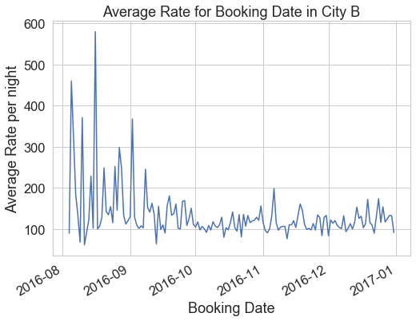

```python
book_date_price_B = exB['ADR_USD'].groupby([exB['booking_date']]).agg('mean')
book_date_price_B

ADR_bookdate_B = plt.figure(figsize=(8, 6))
book_date_price_B.plot(kind="line")
plt.xlabel("Booking Date")
plt.ylabel("Average Rate per night");
plt.title("Average Rate for Booking Date in City B")
ADR_bookdate_B.savefig('Pictures/ADR_bookdate_B.png')
```

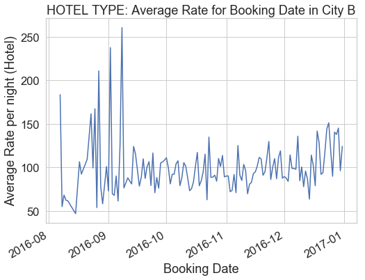

```python
book_date_price_acco_B = exB['ADR_USD'].groupby([exB['accommadation_type_name'], exB['booking_date']]).agg('mean')
book_date_price_acco_B['Hotel']

ADR_bookdate_B_hotel = plt.figure(figsize=(8, 6))
book_date_price_acco_B['Hotel'].plot(kind="line")
plt.xlabel("Booking Date")
plt.ylabel("Average Rate per night (Hotel)");
plt.title("HOTEL TYPE: Average Rate for Booking Date in City B")
ADR_bookdate_B_hotel.savefig('Pictures/ADR_bookdate_B_hotel.png')
```

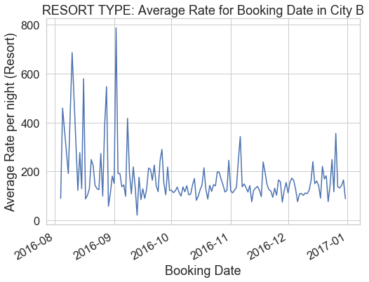

```python
book_date_price_acco_B = exB['ADR_USD'].groupby([exB['accommadation_type_name'], exB['booking_date']]).agg('mean')
book_date_price_acco_B['Resort']

ADR_bookdate_B_resort = plt.figure(figsize=(8, 6))
book_date_price_acco_B['Resort'].plot(kind="line")
plt.xlabel("Booking Date")
plt.ylabel("Average Rate per night (Resort)");
plt.title("RESORT TYPE: Average Rate for Booking Date in City B")
ADR_bookdate_B_resort.savefig('Pictures/ADR_bookdate_B_resort.png')
```

Seems like the price goes down after September in both City A and City B.  
**Looking at the Booking Records plot for both City A and City B, we can see that the booking amount increased a lot starting around the end of September. This might be because of many discounts are provided from each hotel accommodation, that leads to a lower ADR (Average Daily Rate) which we see in the above Average Rate for Booking Date plot.**  
Let's assume that for now. And then, let's take a look at the difference in dates between the booking date and checkin date.

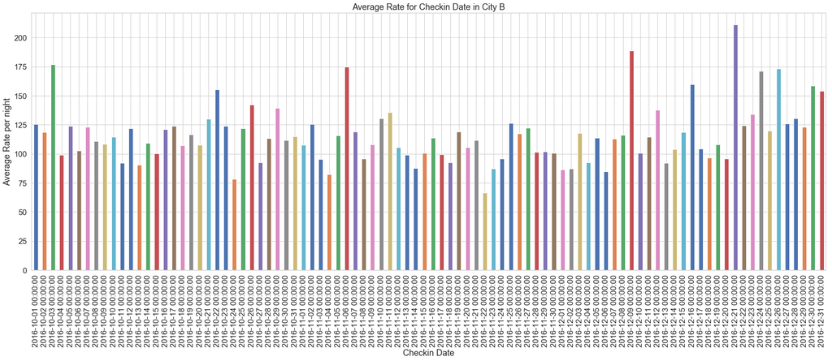

```python
checkin_date_price_B = exB['ADR_USD'].groupby([exB['checkin_date']]).agg('mean')
checkin_date_price_B

plt.figure(figsize=(30, 10))
checkin_date_price_B.plot(kind="bar")
plt.xlabel("Checkin Date")
plt.ylabel("Average Rate per night");
plt.title("Average Rate for Checkin Date in City B")
```